# AutoRegressive Models

AR

# 1 AR(1) model

An autoregressive model of order 1, AR(1), is defined as:
$$y_t = \phi_0 +\phi_1 \ y_{t-1} +\epsilon_t$$
with the following assumptions $\forall t$:

- $\mathbb{E}[\epsilon_t]= 0$, $\mathbb{V}[\epsilon_t]= \sigma_{\epsilon}^2$ and the errors $\epsilon_{t_1}$ and $\epsilon_{t_2}$ are independent $\forall t_1\neq t_2$.
- $\mathbb{E}[y_t]= \mu_y$ (stationary in mean). It can be shown $\mu_t=\frac{\phi_0}{1-\phi_1}$
- $\mathbb{V}[y_t]= \sigma_y^2$ (stationary in variance). It can be shown $\sigma_y^2=\frac{\sigma_{\epsilon}^2}{1-\phi_1^2}$ imposing the constraint $-1<\phi_1<1$.

AR(1) can be rewritten:
$$y_t-\mu_y= \phi_1 \ (y_{t-1}-\mu_y) +\epsilon_t$$
and it can be shown that the covariance between $y_t$ and $y_{t-k}$ is:
$$\mathbb{C}\text{ov}[y_t,y_{t-k}]=(\phi_1)^k \ \sigma_y^2$$
and consequently the correlation between $y_t$ and $y_{t-k}$ is:
$$\mathbb{C}\text{or}[y_t,y_{t-k}]=(\phi_1)^k$$

## 1.1 ACF of AR(1)

This autocorrelation formula explains the ‘exponential decrease’ like shape of the ACF (for $0<\phi_1<1$) simulated below since $ACF(k)=(\phi_1)^k$:

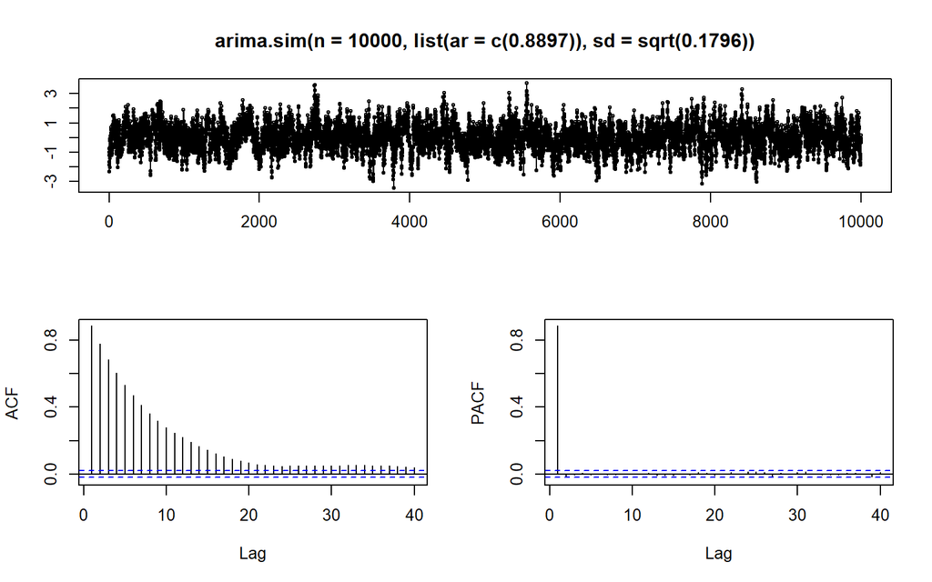

```r
require(fma)
tsdisplay(arima.sim(n=10000,list(ar = c(0.8897)), sd = sqrt(0.1796)))
```

For $-1<\phi_1<0$, a ‘damped sine wave’ appears for the ACF:

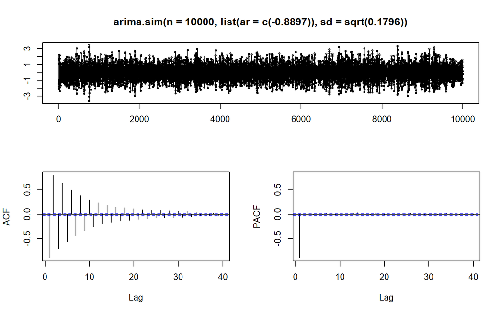

```r
require(fma)
tsdisplay(arima.sim(n=10000,list(ar = c(-0.8897)), sd = sqrt(0.1796)))
```

## 1.2 PACF of AR(1)

An AR(1) model can be rewritten as an AR(p):
$$y_t = \phi_0 +\phi_1 \ y_{t-1} +0 \ y_{t-2}+\cdots +0 \ y_{t-p} +
\epsilon_t$$
defining $PACF(1)=\phi_1$, $PACF(2)=0$ …$PACF(p)=0$ using the parameters associated with the explanatory variables $y_{t-1}$, $y_{t-2}$ … $y_{t-p}$.

Both ACF and PACF can be used for recognising an AR model (and finding its order $p$).

# 2 AR(2) model

AR(2) can be written:
$$y_t-\mu_y= \phi_1 \ (y_{t-1}-\mu_y) +\phi_2 \ (y_{t-2}-\mu_y)
+\epsilon_t$$
where $y_t$ is stationary in mean and variance.

Below is a plot of a simulated time series that follows an AR(2) model with $\phi_1=0.8897$ and $\phi_2=-0.5$. Note how the PACF(1) and PACF(2) are not zeroes while all others coefficients PACF(k) are for $k>2$. The ACF displays a damped sine wave and the time plot shows a contant mean and variance over time (as expected from AR(2)).

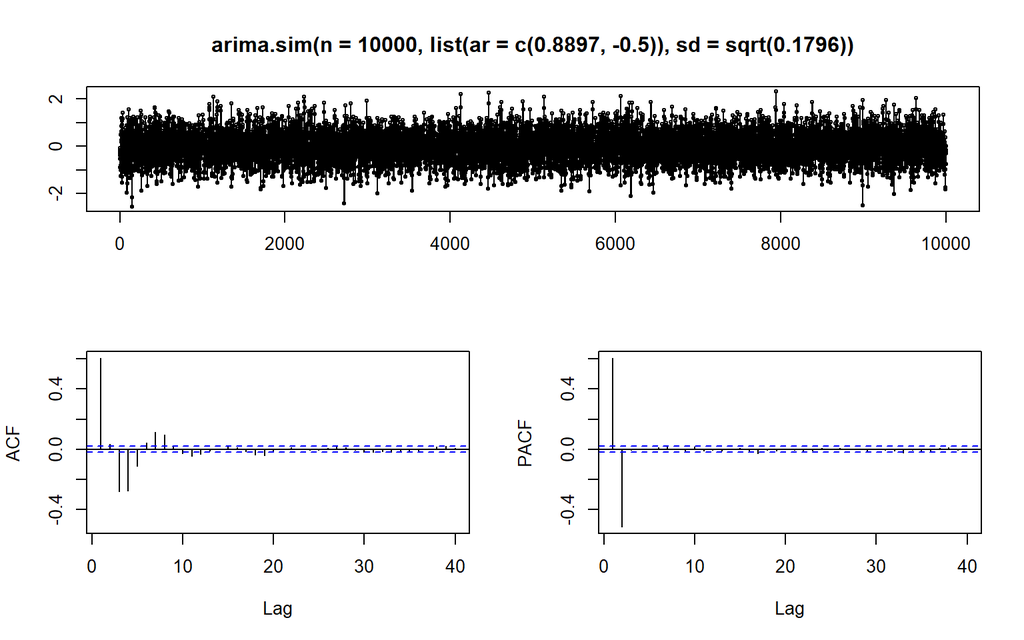

```r
require(fma)
tsdisplay(arima.sim(n=10000,list(ar = c(0.8897,-0.5)), sd = sqrt(0.1796)))
```

**Exercise:** What contraint is there on the parameters $\phi_1$ and $\phi_2$ in an AR(2) ?

# 3 Using differencing before AR(1) does not create AR(2)

Defining $x_t=y_t-y_{t-1}$ as the difference of a time series $y_t$ and Assuming an AR(1) explains $x_t$:
$$x_t-\mu_x = \phi_1 (x_{t-1}-\mu_x) + \epsilon_t$$
For $y_t$, this means:
$$\begin{equation}
y_t-y_{t-1}-\mu_x = \phi_1 (y_{t-1}-y_{t-2}-\mu_x) + \epsilon_t
\end{equation}$$

**Exercise.** could $y_t$ be stationary in mean ?

If $y_t$ is stationary in mean then $\mathbb{E}[y_t]=\mu_y\ \forall t$ and
$$\begin{array}{l}
\left(\mathbb{E}[y_t-y_{t-1}-\mu_x] =\mathbb{E}[ \phi_1
(y_{t-1}-y_{t-2}-\mu_x) + \epsilon_t]\right)\\
\equiv \left( \mu_y -\mu_y-\mu_x = \phi_1 \ (\mu_y-\mu_y-\mu_x) +0
\right)\\
\equiv \left( -\mu_x =- \phi_1 \ \mu_x \right)
\end{array}$$
which is only possible if $\mu_x=0$.

So if $\mu_x \neq 0$ then $y_t$ is not stationary in mean (and cannot be explained by an AR(2)).

**Exercise.** Assuming $\mu_x=0$, what does it mean if $y_t$ stationary in variance ?

We assume $\mu_x=0$, $\mathbb{E}[y_t]=\mu_y \forall t$, and $\mathbb{V}[y_t]=\sigma_y^2 \forall t$

$x_t$ follows an AR(1) that is assumed stationary in variance then
$$\mathbb{E}[x_t^2]=\sigma_x^2 \quad \forall t \ (\text{since} \ \mu_x=0)$$
hence equivalently
$$\mathbb{E}[(y_t-y_{t-1})^2]=\mathbb{E}[(y_t-\mu_y-y_{t-1}+\mu_y)^2]=\sigma_x^2
\quad \forall t$$
leading to
$$2\sigma_y^2 - 2 \gamma_1=\sigma_x^2 \quad (*)$$
using notation $\gamma_1=\mathbb{C}\text{ov}[y_t,y_{t-1}]\ \forall t$.

Using the equation
$$y_t-\mu_y = (1+\phi_1) \ (y_{t-1}-\mu_y) - \phi_1 \ (y_{t-2}-\mu_y) +
\epsilon_t$$
The covariance $\gamma_1$ can also be computed leading to
$$\gamma_1=(1+\phi_1) \sigma_y^2- \phi_1 \gamma_1$$
since $\epsilon_t$ is not correlated with $(y_{t-1}-\mu_y)$.
$$\gamma_1=\sigma_y^2 \quad (**)$$
Using $(*)$ and $(**)$ we get $\sigma_x^2=0$.

Conclusion: $y_t$ is not an AR(2) in general because it is not stationary in mean and variance at the exception of the case when $x_t$ is having contant value 0 (!).

# 4 Using arima.sim in R

Below a time series $y_t$ is created such that the time series $x_t=y_t-y_{t-1}$ follows AR(1). Note how the ACF coefficient remains high indicating that there is a trend in the time series.

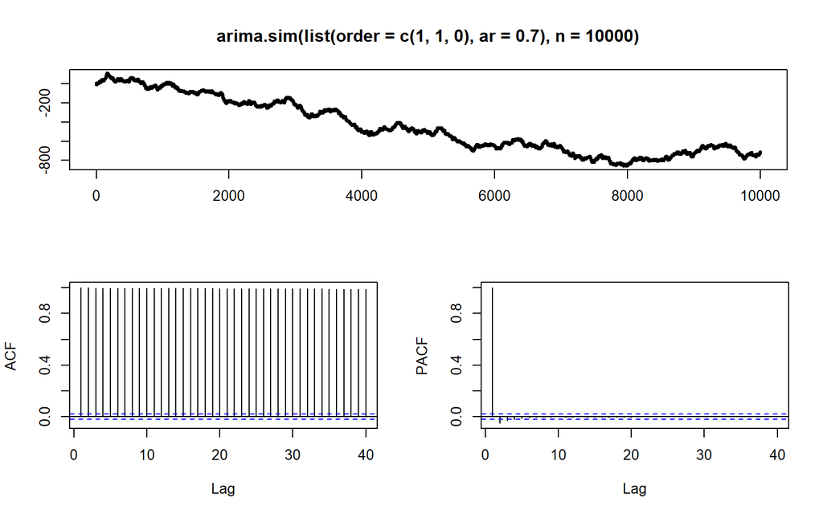

```r
require(fma)
tsdisplay(arima.sim(list(order = c(1,1,0), ar = 0.7), n = 10000))
```